# lab10_Aditya_Mhaske

[Run in Google Colab](https://colab.research.google.com/github/yy/dviz-course/blob/master/docs/m10-logscale/lab10.ipynb)

[figure not shown]

View on Github

[figure not shown]

View raw on Github

# Module 10: Logscale

```python
import matplotlib.pyplot as plt
import pandas as pd
import seaborn as sns
import numpy as np
import scipy.stats as ss
import vega_datasets
```

## Ratio and logarithm

If you use linear scale to visualize ratios, it can be quite misleading.

Let's first create some ratios.

```python
x = np.array([1,    1,   1,  1, 10, 100, 1000])
y = np.array([1000, 100, 10, 1, 1,  1,   1   ])
ratio = x/y
print(ratio)
```

```
[1.e-03 1.e-02 1.e-01 1.e+00 1.e+01 1.e+02 1.e+03]
```

**Q: Plot on the linear scale using the [`scatter()`](http://matplotlib.org/examples/shapes_and_collections/scatter_demo.html) function. Also draw a horizontal line at ratio=1 for a reference.**

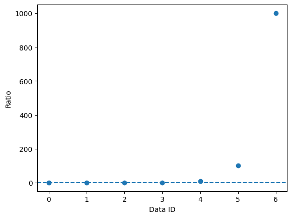

```python
X = np.arange(len(ratio))

# Implement

# YOUR SOLUTION HERE

plt.scatter(X, ratio, label='Ratio')
plt.axhline(y=1, linestyle='--', label='Reference')
plt.xlabel('Data ID')
plt.ylabel('Ratio')
plt.show()
```

**Q: Is this a good visualization of the ratio data? Why? Why not? Explain.**

The provided visualization, which includes a scatter plot of the ratio data along with a horizontal reference line at a ratio of 1, is a reasonable way to represent the data, but it may not be the best choice depending on the specific context and the goals of the visualization.

Pros:

Cons:

Limited Insights: While the plot clearly displays the data points and their relationship to the reference line, it doesn't provide much additional insight or context about the data. For more complex datasets, additional visualizations or statistical analysis may be needed to draw meaningful conclusions.

Context Dependence: The suitability of this visualization depends on the specific goals and audience. If the goal is to compare ratios to a reference value, it works well. However, if the goal is to uncover patterns or trends in the data, other visualization types like line charts or box plots might be more informative.

**Q: Can you fix it?**

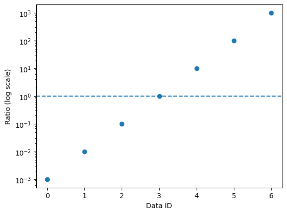

```python
# Implement

# YOUR SOLUTION HERE

plt.scatter(X, ratio, label='Ratios', marker='o')
plt.axhline(y=1, linestyle='--', label='Ratio = 1')
plt.yscale('log')
plt.xlabel('Data ID')
plt.ylabel('Ratio (log scale)')
plt.show()
```

## Log-binning

Let's first see what happens if we do not use the log scale for a dataset with a heavy tail.

**Q: Load the movie dataset from `vega_datasets` and remove the NaN rows based on the following three columns: `IMDB Rating`, `IMDB Votes`, `Rotten Tomatoes Rating`.**

```python
# Implement

# YOUR SOLUTION HERE

movies = vega_datasets.data.movies()
columns_with_nan = ['IMDB_Rating', 'IMDB_Votes', 'Rotten_Tomatoes_Rating']
movies = movies.dropna(subset=columns_with_nan)
movies.head()
```

|  | Title | US_Gross | Worldwide_Gross | US_DVD_Sales | Production_Budget | Release_Date | MPAA_Rating | Running_Time_min | Distributor | Source | Major_Genre | Creative_Type | Director | Rotten_Tomatoes_Rating | IMDB_Rating | IMDB_Votes |
| --- | --- | --- | --- | --- | --- | --- | --- | --- | --- | --- | --- | --- | --- | --- | --- | --- |
| 4 | Slam | 1009819.0 | 1087521.0 | NaN | 1000000.0 | Oct 09 1998 | R | NaN | Trimark | Original Screenplay | Drama | Contemporary Fiction | None | 62.0 | 3.4 | 165.0 |
| 8 | Pirates | 1641825.0 | 6341825.0 | NaN | 40000000.0 | Jul 01 1986 | R | NaN | None | None | None | None | Roman Polanski | 25.0 | 5.8 | 3275.0 |
| 9 | Duel in the Sun | 20400000.0 | 20400000.0 | NaN | 6000000.0 | Dec 31 2046 | None | NaN | None | None | None | None | None | 86.0 | 7.0 | 2906.0 |
| 10 | Tom Jones | 37600000.0 | 37600000.0 | NaN | 1000000.0 | Oct 07 1963 | None | NaN | None | None | None | None | None | 81.0 | 7.0 | 4035.0 |
| 11 | Oliver! | 37402877.0 | 37402877.0 | NaN | 10000000.0 | Dec 11 1968 | None | NaN | Sony Pictures | None | Musical | None | None | 84.0 | 7.5 | 9111.0 |

If you simply call `hist()` method with a dataframe object, it identifies all the numeric columns and draw a histogram for each.

**Q: draw all possible histograms of the movie dataframe. Adjust the size of the plots if needed.**

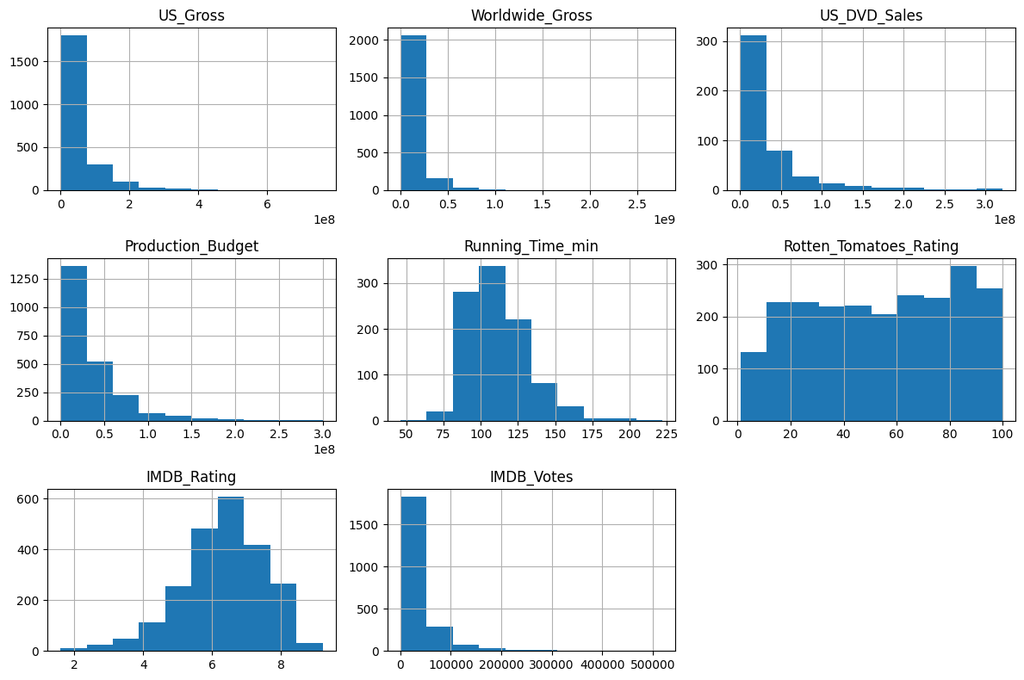

```python
# Implement

# YOUR SOLUTION HERE

numeric_columns = movies.select_dtypes(include=['number'])
num_columns = len(numeric_columns.columns)
num_rows = (num_columns + 2) // 3

plt.figure(figsize=(12, 8))

for i, column in enumerate(numeric_columns.columns):
    plt.subplot(num_rows, 3, i + 1)
    plt.hist(movies[column], bins=10)
    plt.title(column)

    plt.grid(True)

plt.tight_layout()
plt.show()
```

As we can see, a majority of the columns are not normally distributed. In particular, if you look at the worldwide gross variable, you only see a couple of meaningful data from the histogram. Is this a problem of resolution? How about increasing the number of bins?

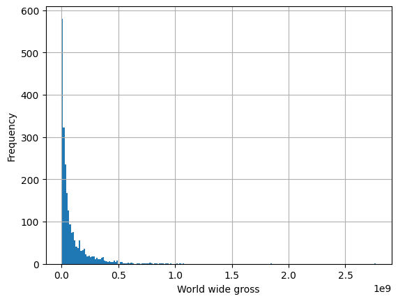

```python
ax = movies["Worldwide_Gross"].hist(bins=200)
ax.set_xlabel("World wide gross")
ax.set_ylabel("Frequency")
```

Maybe a bit more useful, but it doesn't tell anything about the data distribution above certain point. How about changing the vertical scale to logarithmic scale?

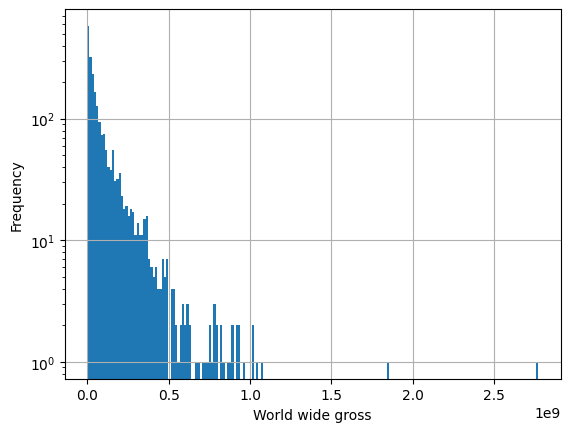

```python
ax = movies["Worldwide_Gross"].hist(bins=200)
ax.set_yscale('log')
ax.set_xlabel("World wide gross")
ax.set_ylabel("Frequency")
```

Now, let's try log-bin. Recall that when plotting histgrams we can specify the edges of bins through the `bins` parameter. For example, we can specify the edges of bins to [1, 2, 3, ... , 10] as follows.

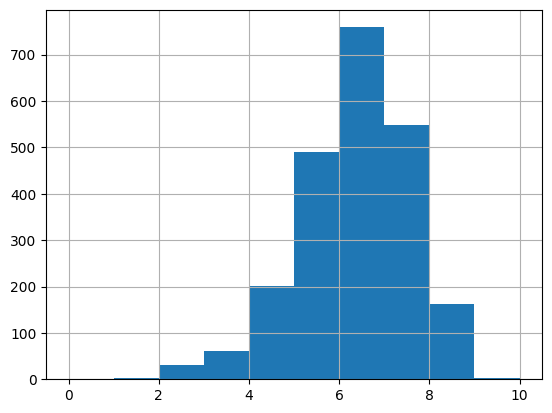

```python
movies["IMDB_Rating"].hist(bins=range(0,11))
```

Here, we can specify the edges of bins in a similar way. Instead of specifying on the linear scale, we do it on the log space. Some useful resources:

- [Google query: python log-bin](https://www.google.com/webhp?sourceid=chrome-instant&ion=1&espv=2&ie=UTF-8#q=python+log-bin&pws=0)
- [numpy.logspace](http://docs.scipy.org/doc/numpy/reference/generated/numpy.logspace.html)
- [numpy.linspace vs numpy.logspace](http://stackoverflow.com/questions/31480033/difference-in-output-between-numpy-linspace-and-numpy-logspace)

Hint: since $10^{\text{start}} = \text{min(Worldwide_Gross)}$, $\text{start} = \log_{10}(\text{min(Worldwide_Gross)})$

```python
min(movies["Worldwide_Gross"])
```

```
0.0
```

Because there seems to be movie(s) that made $0, and because log(0) is undefined & log(1) = 0, let's add 1 to the variable.

```python
movies["Worldwide_Gross"] = movies["Worldwide_Gross"]+1.0
```

```python
# TODO: specify the edges of bins using np.logspace

# YOUR SOLUTION HERE

bins = np.logspace(np.log10(movies["Worldwide_Gross"].min()), np.log10(movies["Worldwide_Gross"].max()), 20)
bins
```

```
array([1.00000000e+00, 3.14018485e+00, 9.86076088e+00, 3.09646119e+01,
       9.72346052e+01, 3.05334634e+02, 9.58807191e+02, 3.01083182e+03,
       9.45456845e+03, 2.96890926e+04, 9.32292387e+04, 2.92757043e+05,
       9.19311230e+05, 2.88680720e+06, 9.06510822e+06, 2.84661155e+07,
       8.93888645e+07, 2.80697558e+08, 8.81442219e+08, 2.76789150e+09])
```

Now we can plot a histgram with log-bin. Set both axis to be log-scale.

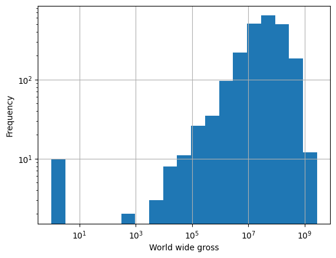

```python
ax = (movies["Worldwide_Gross"]+1.0).hist(bins=bins)
ax.set_yscale('log')
ax.set_xscale('log')
ax.set_xlabel("World wide gross")
ax.set_ylabel("Frequency")
```

What is going on? Is this the right plot?

**Q: explain and fix**

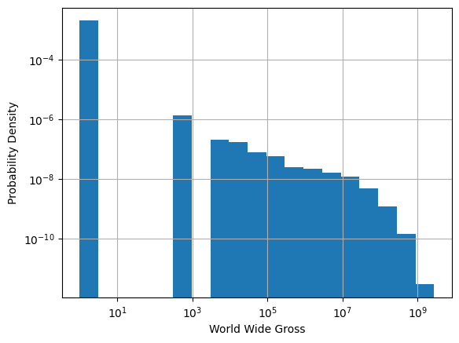

```python
# Implement

# YOUR SOLUTION HERE


plt.hist((movies["Worldwide_Gross"]+1.0), bins=bins, density=True)

plt.xscale('log')
plt.yscale('log')
plt.xlabel("World Wide Gross")
plt.ylabel("Probability Density")
plt.grid(True)
plt.show()
```

**Q: Can you explain the plot? Why are there gaps?**

```python
# YOUR SOLUTION HERE
```

X-Axis (World Wide Gross): The x-axis represents the "World Wide Gross" values of movies, which are presented in a logarithmic scale. This means that the spacing between values increases exponentially as you move to the right on the x-axis. The bins are designed to cover a wide range of gross values effectively.

Y-Axis (Probability Density): The y-axis represents the probability density. Probability density is a measure of the likelihood of a continuous random variable (in this case, "World Wide Gross") falling within a particular range of values. The y-values are also presented in a logarithmic scale.

Gaps: The gaps in the plot are due to the binning process. In a log-binned histogram, the bin edges are spaced logarithmically. This means that smaller bins are used to represent the lower values and larger bins for the higher values. As a result, there can be gaps in the histogram when there are no data points falling within certain bin ranges. This is typical when dealing with data that has a wide range of values and can be more easily visualized in log space. The gaps are a natural consequence of the logarithmic binning and scaling.

The plot is a way to represent the distribution of "World Wide Gross" values with a focus on highlighting the behavior in different ranges of the data, especially when the data spans several orders of magnitude. The logarithmic scaling helps in visualizing both low and high values effectively.

## CCDF

CCDF is a nice alternative to examine distributions with heavy tails. The idea is same as CDF, but the direction of aggregation is opposite.

**Q: Draw a CCDF of worldwide gross data in log-log scale**

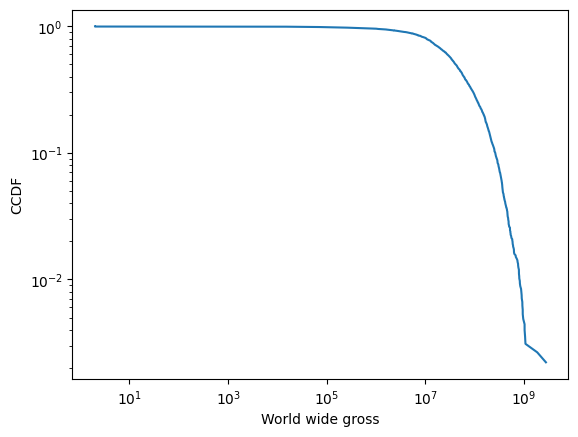

```python
# Implement

# YOUR SOLUTION HERE
movies["Worldwide_Gross"] = movies["Worldwide_Gross"] + 1.0
worldgross_sorted = np.sort(movies["Worldwide_Gross"])
N = len(worldgross_sorted)

Y = np.linspace(1.0, 1 / N, num=N)

plt.loglog(worldgross_sorted, Y)

plt.xlabel("World wide gross")
plt.ylabel("CCDF")
plt.show()
```

We can also try in semilog scale (only one axis is in a log-scale), where the horizontal axis is linear.

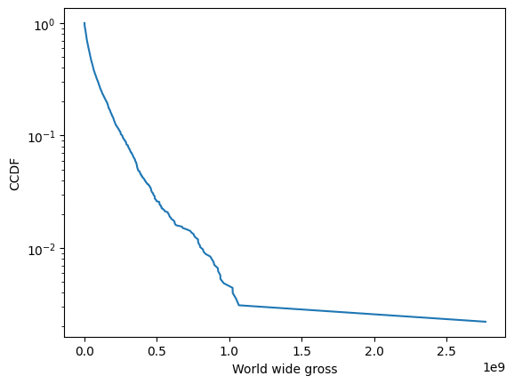

```python
plt.xlabel("World wide gross")
plt.ylabel("CCDF")
plt.plot(worldgross_sorted,Y)
plt.yscale('log')
```

A straight line in semilog scale means exponential decay (cf. a straight line in log-log scale means power-law decay). So it seems like the amount of money a movie makes across the world follows *roughly* an exponential distribution, while there are some outliers that make insane amount of money.

**Q: Which is the most successful movie in our dataset?**

You can use the following

- `idxmax()`: https://pandas.pydata.org/pandas-docs/stable/generated/pandas.DataFrame.idxmax.html
- `loc`: https://pandas.pydata.org/pandas-docs/stable/generated/pandas.DataFrame.loc.html

```python
# Implement

# YOUR SOLUTION HERE

movie_S = movies["Worldwide_Gross"].idxmax()
movie_S = movies.loc[movie_S]
movie_S
```

```
Title                                  Avatar
US_Gross                          760167650.0
Worldwide_Gross                  2767891501.0
US_DVD_Sales                      146153933.0
Production_Budget                 237000000.0
Release_Date                      Dec 18 2009
MPAA_Rating                             PG-13
Running_Time_min                          NaN
Distributor                  20th Century Fox
Source                    Original Screenplay
Major_Genre                            Action
Creative_Type                 Science Fiction
Director                        James Cameron
Rotten_Tomatoes_Rating                   83.0
IMDB_Rating                               8.3
IMDB_Votes                           261439.0
Name: 1234, dtype: object
```